# The Small Agent That Actually Stuck

*The loud story about AI agents is autonomous swarms that build companies overnight. The quiet one, the agents people actually keep, is a thing that texts you every morning and nags you until you take your medication. The boring ones won.*

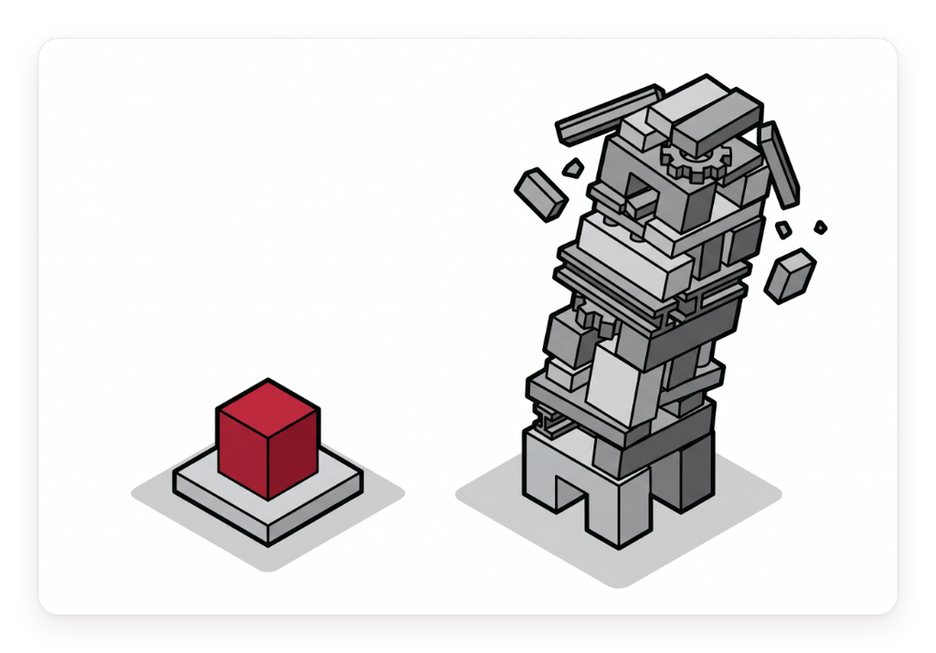

I went looking for what people actually use AI agents for, not what they demo, and the answer made me laugh.

The most upvoted answers are almost embarrassingly small. One person built an agent named Hobson whose entire job is to send a morning news briefing and then remind them to take their medication, and it will not stop pestering until they confirm they did. Another turned their resume into a personal landing page while job hunting. A third gets a daily summary of overnight email and calendar so they start the day already oriented. None of these is an autonomous empire. Each does one small thing, every day, reliably. And those are the ones that stuck.

Meanwhile the agents that were supposed to change everything, the ten-tool, multi-agent, plan-your-whole-life systems, mostly get built, demoed once, and quietly abandoned. There is a lesson in that gap, and it is the opposite of what the hype tells you to build.

**Three things to take away:**

- The agents people keep are narrow, boring, and reliable. The agents people abandon are broad, impressive, and flaky. Reliability on a small job beats brilliance on a big one, every time, because you only keep a tool you can trust.
- A narrow agent works because its job is small enough to have an obvious definition of done. "Did you take your medication, yes or no" is checkable. "Manage my life" is not. The scope is what makes it reliable, not the model.
- If you are building agents, shrink the scope until the thing is right every single time, then earn the next bit of trust. Start with the small agent that works, not the autonomous one that almost does.

## What people actually keep

Spend an hour in the communities where people share what they have built, and the pattern is consistent enough to be funny. The agents that earn a permanent place in someone's day are tiny. A morning briefing. A medication nudge that refuses to take silence for an answer. A bill that gets categorized. A standup summary. A single recurring annoyance, removed.

What you do not see near the top is the autonomous everything-machine. Those threads exist, full of orchestration diagrams, but they are about building agents, not about living with them. The most-upvoted advice to beginners is blunt about this: do not start with agents at all. Most people jump straight into multi-agent systems and memory architectures before they have shipped one simple thing that actually runs. They build the cathedral and never light a candle in it.

The split is not about skill. The people running the impressive systems are often more capable than the person whose agent just nags them about pills. The split is about what survives contact with daily use, and what survives is the thing that is right every time.

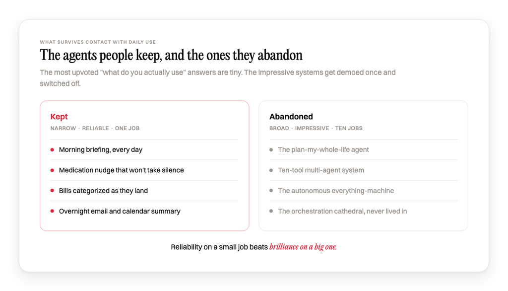

## Why the small ones stick

The reason is trust, and trust is built the same way with software as with people: by being right, repeatedly, on something that matters a little. A narrow agent gets a lot of small chances to be right and almost none to be catastrophically wrong. Every morning the briefing shows up, the reminder fires, the answer is correct. The agent becomes a habit, and a habit is the highest score a tool can get.

A broad autonomous agent gets the math backwards. It has a huge surface area, so it has many ways to be wrong, and the first time it does something strange, books the wrong meeting, emails the wrong person, spends money you did not expect, it does not just lose that task. It loses your trust, and a tool you do not trust is a tool you stop opening. Impressive seventy percent of the time is worse than dependable ninety-nine percent of the time, because the thirty percent is where the trust drains out, and trust does not come back at the rate it leaves.

That is the whole asymmetry. Reliability compounds into a habit you keep. Flakiness compounds into a thing you delete. The small agent wins not because it does more, but because it never makes you regret relying on it.

## The scope is what makes it reliable

Here is the part builders most often get backwards. They reach for a smarter model to make a broad agent reliable, when the lever is the scope, not the model.

A medication reminder is reliable because its job is small enough to have an unambiguous definition of done. There is a clean question, did you take it, a clean answer, yes or no, and a clean action, keep nagging until yes. The agent cannot really fail at that, because there is nowhere for ambiguity to hide. Now widen the job to "manage my health" and every part of that clarity dissolves. What counts as done is suddenly a matter of judgment, and the same model that was flawless on the narrow task starts guessing on the broad one.

This connects to the only framing that has held up for me across a lot of agent projects. The human's job is to set the bar, to define what good looks like clearly enough that the work can be checked against it. A narrow agent is one where the bar is so obvious it almost sets itself. A broad autonomous agent is one where nobody can state the bar, which is exactly why nobody can tell when it has failed. Narrow scope is not a limitation you accept. It is the thing that makes the agent checkable, and checkable is what makes it reliable.

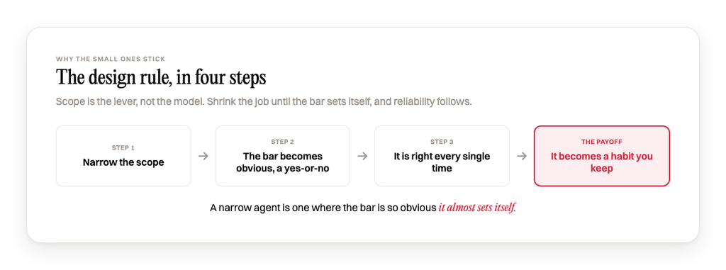

## Build the small one first

If you are deciding what to ship, the instruction falls right out of this. Pick the one recurring annoyance you understand completely. Shrink the agent's job until its definition of done is a question you could answer yes or no without thinking. Make it right every single time on that one job, and let it earn a place in someone's day. Only then, with trust in the bank, widen the scope by one notch and see if it still holds.

This is the opposite of how most agent projects start, which is with an architecture diagram and a list of ten capabilities. The ten-capability agent is impressive in the pitch and absent from anyone's daily life six weeks later. The one-capability agent is unimpressive in the pitch and still running a year on, because it never gave anyone a reason to turn it off.

There is a quieter reason this matters for anyone building a product. The narrow agent is also the one you can actually stand behind. You can test it, you can predict it, you can promise a customer it will do the thing, because the thing is small enough to guarantee. The autonomous one you can only hope about, and hope is not a feature you can sell twice.

## The boring future

The picture of the agent future that gets the attention is a swarm of autonomous systems running a company while the founder sleeps. The picture that is actually showing up in people's lives is smaller and stranger: a growing collection of tiny, boring, dependable helpers, each removing one specific friction, none of them trying to run anything.

That future is less cinematic and far more likely, because it is built on the only currency that compounds, which is trust. The agent that texts you about your medication will never trend. It will also still be running long after the autonomous everything-machine has been quietly switched off. If you want to build something people keep, build the small thing that is right every time, and let it be boring. Boring is what stuck.

*If this was useful, forward it to whoever on your team keeps pitching the ten-capability agent. The one-capability one is the one that ships.*

*My books on Amazon: Claude Code for Everyone Else (https://www.amazon.com/dp/B0H35YY851) and From Vibe to Production (https://www.amazon.com/dp/B0H34GK9VW).*

*I also take on a small number of mentees one-on-one on MentorCruise: https://mentorcruise.com/mentor/marcokotrotsos/.*